# Untitled

Amanda Murphy

12/1/2021

#The study from 2018, Coordinating bodies and minds: Behavioral synchrony fosters mentalizing, assessed the relationship between synchornized movements of the body with others and likeliness of considering other’s thoughts and mental states as a form of empathy. The idea was that following movements synchronously with other people also encourages people to become cognitively engaged in reasoning with others’ mental states.

#Citation: # Baimel, Birch, S. A. ., & Norenzayan, A. (2018). Coordinating bodies and minds: Behavioral synchrony fosters mentalizing. Journal of Experimental Social Psychology, 74, 281–290. https://doi.org/10.1016/j.jesp.2017.10.008

#Data from Experiment 1 # https://osf.io/5d4f6/

```r
library(data.table)
experiment_1 <- fread("experiment1.csv")
```

```r
library(data.table)



#async or sync
#async = 0, sync = 1
experiment_1$condition
```

```
##   [1] 1 1 1 1 1 1 1 1 1 1 1 1 1 1 1 1 1 1 1 1 1 1 1 1 1 0 0 0 0 0 0 0 0 0 0 0 0
##  [38] 0 0 0 0 0 0 0 0 0 0 0 0 0 0 0 0 0 0 1 1 1 1 1 1 1 1 1 1 1 1 1 1 1 1 1 0 0
##  [75] 0 0 0 0 0 0 0 0 0 0 0 0 0 0 0 0 0 0 0 0 0 0 0 0 0 0 0 0 0 0 1 1 1 1 1 1 1
## [112] 1 1 1 1 1
```

```r
experiment_1$condition <- as.factor(experiment_1$condition)
levels(experiment_1$condition) <- c("async","sync")
```

```r
library(ggplot2)
library(dplyr)
#mean for DV: Empathy Quotient

Empathy_quotient <- experiment_1$eqtot


dependent_variable <-     mean(Empathy_quotient)

st_dev <- sd(Empathy_quotient)

SE <- sd(Empathy_quotient)/sqrt(length(Empathy_quotient))
```

#independent T-test replication

```r
t.test(Empathy_quotient~condition, data = experiment_1, var.equal = TRUE)
```

```
##
##  Two Sample t-test
##
## data:  Empathy_quotient by condition
## t = -1.9999, df = 114, p-value = 0.04789
## alternative hypothesis: true difference in means between group async and group sync is not equal to 0
## 95 percent confidence interval:
##  -7.5447496 -0.0358956
## sample estimates:
## mean in group async  mean in group sync
##            42.20968            46.00000
```

#table of means

```r
means_empathyqt <- experiment_1 %>%
  group_by(condition) %>%
  summarize(means = mean(eqtot))

# print table of means
knitr::kable(means_empathyqt)
```

| condition | means |
| --- | --- |
| async | 42.20968 |
| sync | 46.00000 |

#graph table of means

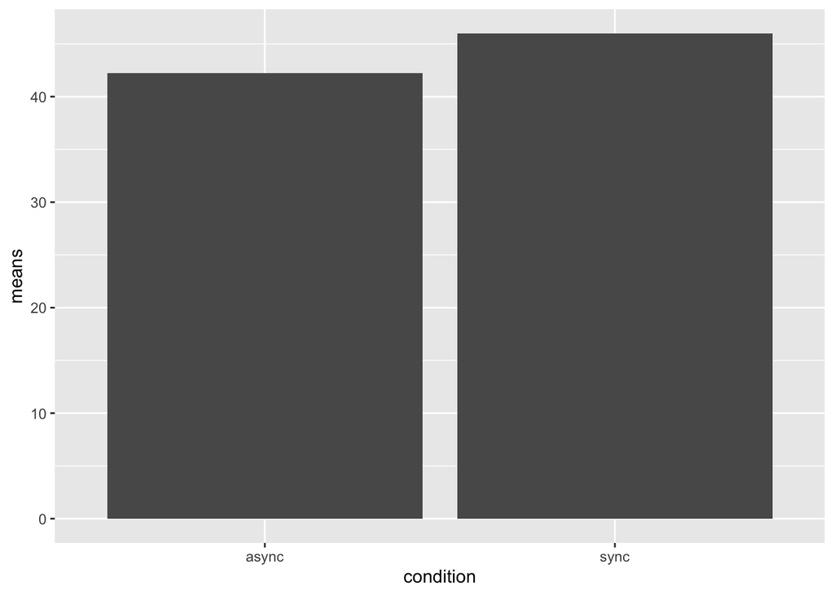

```r
ggplot(means_empathyqt, aes(x=condition, y=means)) +
  geom_bar(stat="identity")
```

#from original paper: ###Empathy Quotient scores were higher in the synchronous condition (M = 46.00, SD = 9.86) than in the asynchronous condition (M = 42.21, SD = 10.45); t(113.26) = − 2.01, p = .047, d = 0.37, .95CI = [0.00, 0.74].

#In the replicated analysis of the data from Experiment 1, I found a slightly different t variable from the independent t test calculation. I found t = -1.9999, df = 114, p-value = 0.04789, which was slightly different then the reported t(113.26) = − 2.01, p = .047. I for some reason have a different degrees of freedom than in the paper’s report, which may account for the slight difference in t value and pvalue reported.

#Mean groups between the two conditions: ‘sync and async’ for the empathy quotient were reported from the orginal paper as : (M = 46.00, SD = 9.86) than in the asynchronous condition (M = 42.21, SD = 10.45). This was congruent with what I found for the mean in group async = 42.20968 and mean in the sync group = 46.

#I believe I was somewhat successful in reproducing these results, although am now wondering if my standard error for this experiment was calculated correctly. Also, I am not sure with the difference of degree’s of freedom used.